# Lecture 4 cont: ggplot2

# ggplot2 R package for Data Visualization

- ggplot is a function in the [ggplot2](https://cran.r-project.org/web/packages/ggplot2/index.html) package and is based on **The Grammar of Graphics** by Leland Wilkinson, and the [lattice](https://cran.r-project.org/web/packages/lattice/index.html) package
- ggplot is designed to work in a *layered fashion*, starting with a layer showing the raw data then adding layers of annotation and statistical summaries

## ggplot() function

Let’s look at an example **diamonds** data that comes with the [ggplot2](https://cran.r-project.org/web/packages/ggplot2/index.html) package. But first, let’s load the the package to our session using the **library()** function. If you have not yet installed the ggplot2 package, you should do this first (you only have to do this once). Recall the magic command is: install.packages(““)

Some information about the **diamonds** dataset :

- ~54,000 round diamonds from http://www.diamondse.info/
- Variables:
  - carat, colour, clarity, cut
  - total depth, table, depth, width, height
  - price
- A question of interest: What is the relationship between *carat* and *price*, and how does it depend on other factors?

## Data on diamonds

Load the **diamonds** data set, get the dimensions, and look at the first few lines

```r
data(diamonds, package="ggplot2")
dim(diamonds)
# [1] 53940    10
head(diamonds)
# # A tibble: 6 × 10
#   carat cut       color clarity depth table price     x     y     z
#   <dbl> <ord>     <ord> <ord>   <dbl> <dbl> <int> <dbl> <dbl> <dbl>
# 1  0.23 Ideal     E     SI2      61.5    55   326  3.95  3.98  2.43
# 2  0.21 Premium   E     SI1      59.8    61   326  3.89  3.84  2.31
# 3  0.23 Good      E     VS1      56.9    65   327  4.05  4.07  2.31
# 4  0.29 Premium   I     VS2      62.4    58   334  4.2   4.23  2.63
# 5  0.31 Good      J     SI2      63.3    58   335  4.34  4.35  2.75
# 6  0.24 Very Good J     VVS2     62.8    57   336  3.94  3.96  2.48
```

## Refresher: Default R plot of price versus carat

Recall using the *default settings* with the **plot()** function

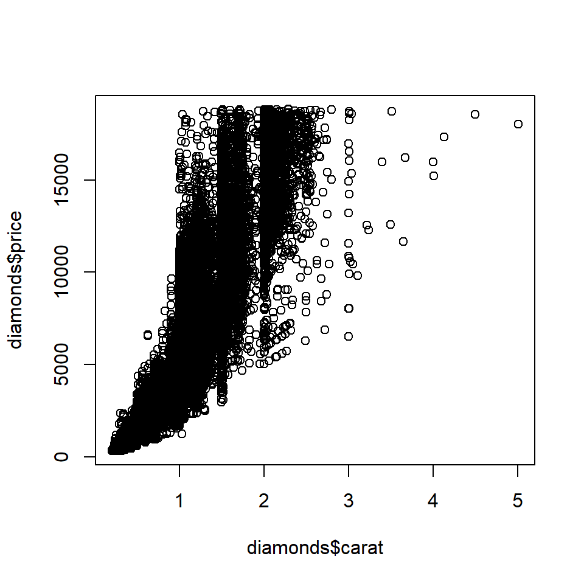

```r
plot(diamonds$carat,diamonds$price) # x-variable first in this notation
```

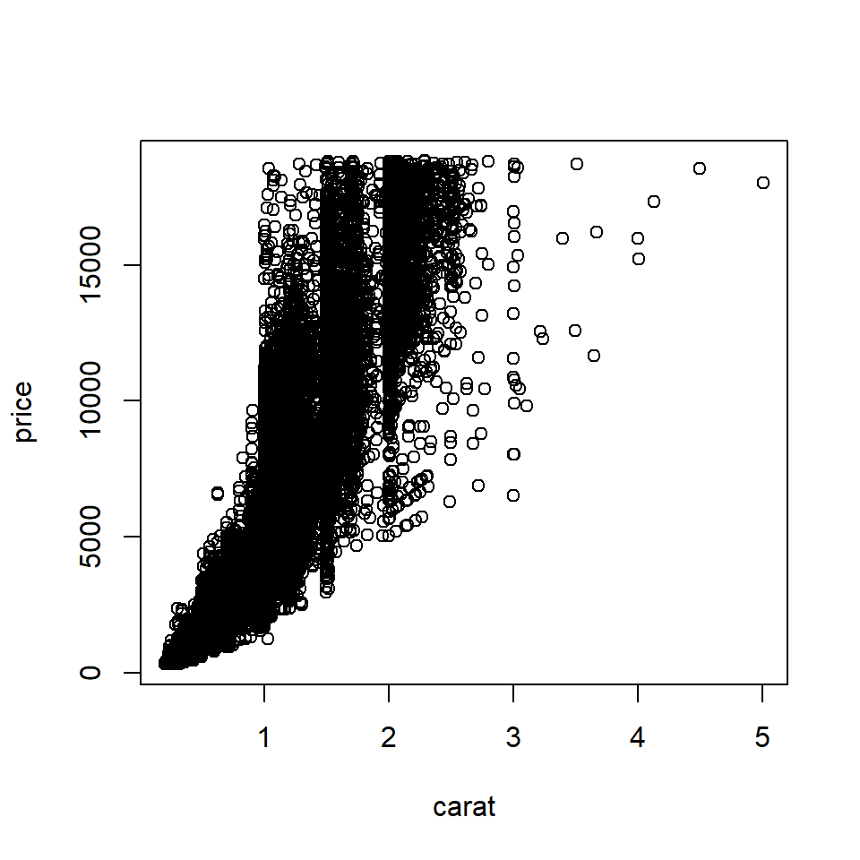

```r
# or
plot(price~carat, data=diamonds) # an alternative way: this is y against x
```

Note: If you want to change the figure size and add a figure caption in Rmd, you can specify the fig.height, fig.width, fig.cap options inside curly brackets at the beginning of your R code chunk. See the full set of options [here](https://rpubs.com/Lingling912/870659) Bonus: If you don’t want to set the size each time you generate a plot, you can insert the options, e.g., fig_width fig_height in your YAML chunk at the beginning of your Rmd file.

## Default ggplot price versus diamonds

Here comes ggplot! Using the *default settings* in **ggplot()**

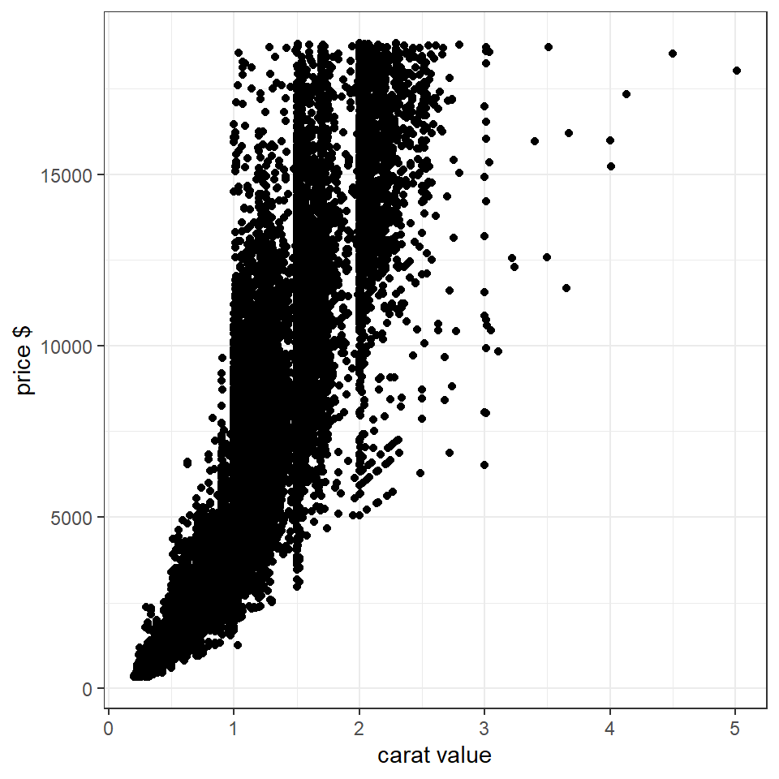

```r
theme_set(theme_bw())
library(ggplot2)
ggplot(diamonds, aes(x=carat,y=price)) +
                          geom_point() +
                          labs(y = 'price $', x = 'carat value')
```

## At first glance

- The *default* option in **ggplot** looks nicer!
- **ggplot**’s syntax looks weird, especially if you’re not very familiar with **lattice**
- Note: It is possible to manipulate the **plot()** options to get a plot similar to ggplot (and maybe even a better one), but that would require a lot of extra coding!!
- The ggplot *syntax* also makes plotting more **structured** and easier to update

## ggplot syntax

ggplot(diamonds, aes(x=carat,y=price)) + geom_point()

*The first component (before the “+”) calls the ggplot function, and the data with x-y varibles.* The second component (after the first “+”) tells ggplot what type of plot you want, e.g., geom_bar/geom_hist/geom_boxplot * Possible to add other lines for more customization on the plot, e.g., title, label for the axes, etc. ** https://rkabacoff.github.io/datavis/ a whole book on ggplot2 customization!!

## geom_boxplot

Very easy to switch to a boxplot. We can use **geom_boxplot** to create boxplots when one variable is continuous and the other is a factor.

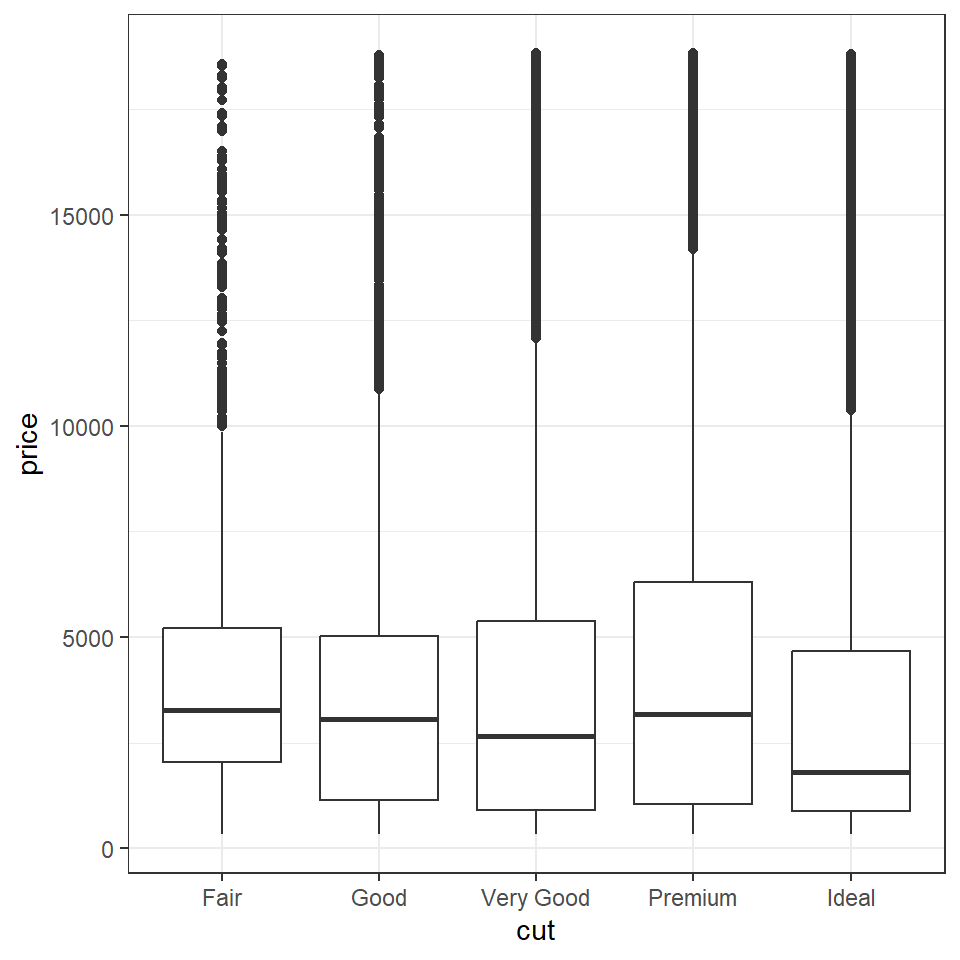

```r
ggplot(diamonds, aes(x=cut,y=price)) + geom_boxplot()
```

## Changing the aesthetics

You can control the aesthetics of each layer, e.g. *colour*, *size*, *shape*, *alpha* (opacity) etc. https://ggplot2.tidyverse.org/reference/geom_point.html

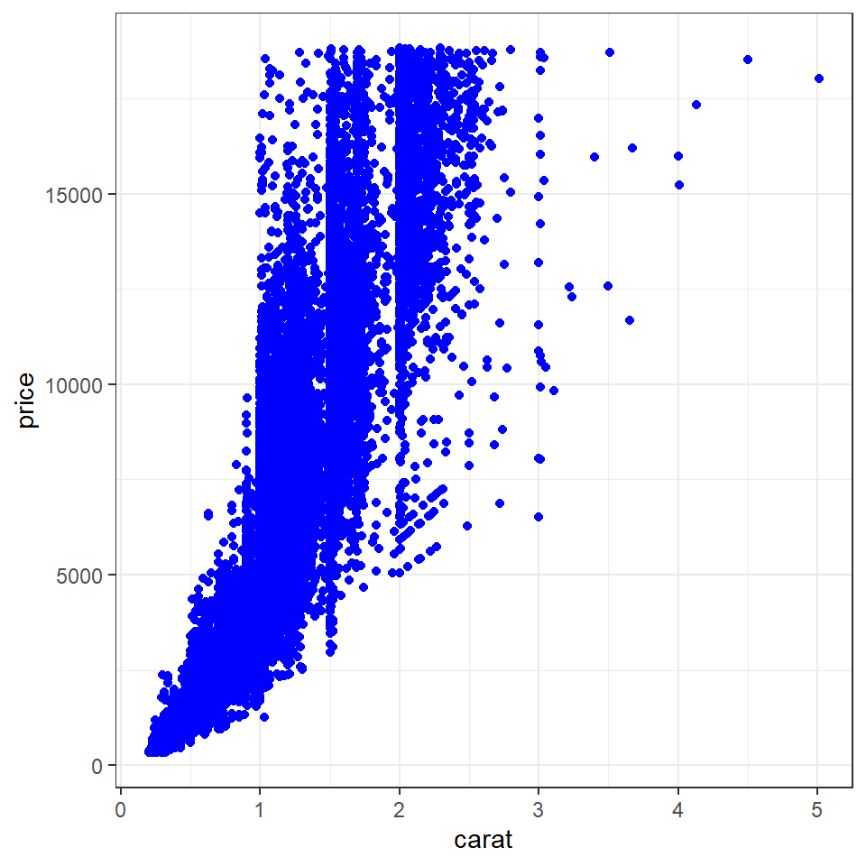

```r
ggplot(diamonds, aes(carat, price)) + geom_point(col = "blue")
```

## A few more examples

Changing the alpha level

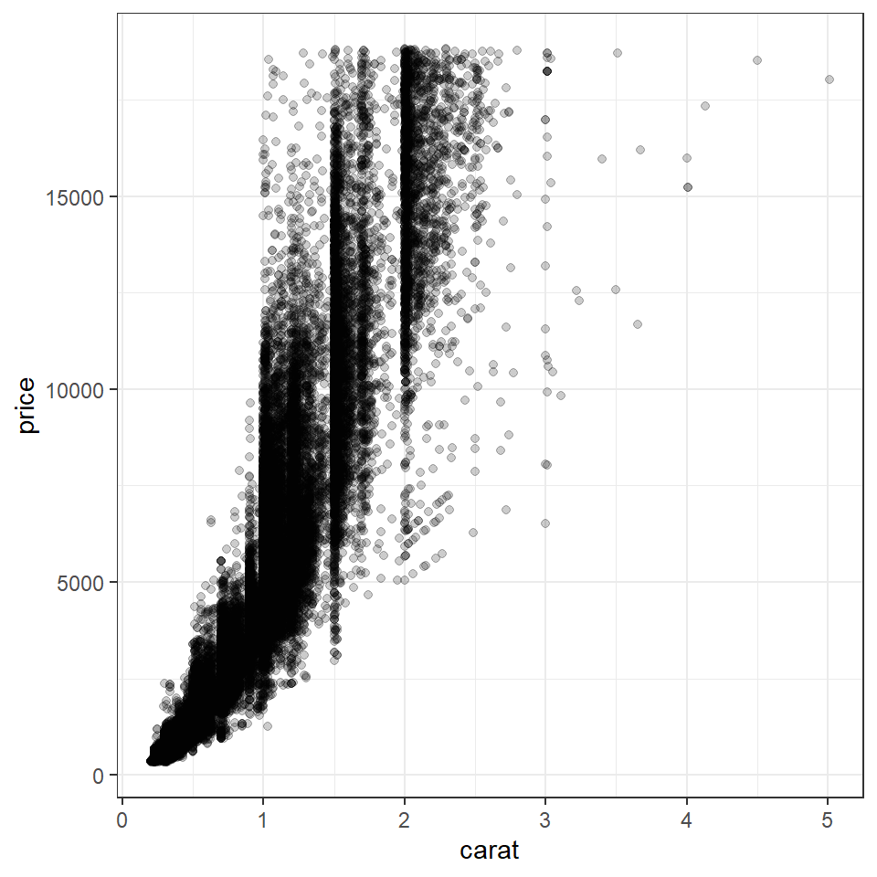

```r
ggplot(diamonds, aes(x=carat,y=price)) + geom_point(alpha = 0.2)
```

## A few more examples

Changing the point size

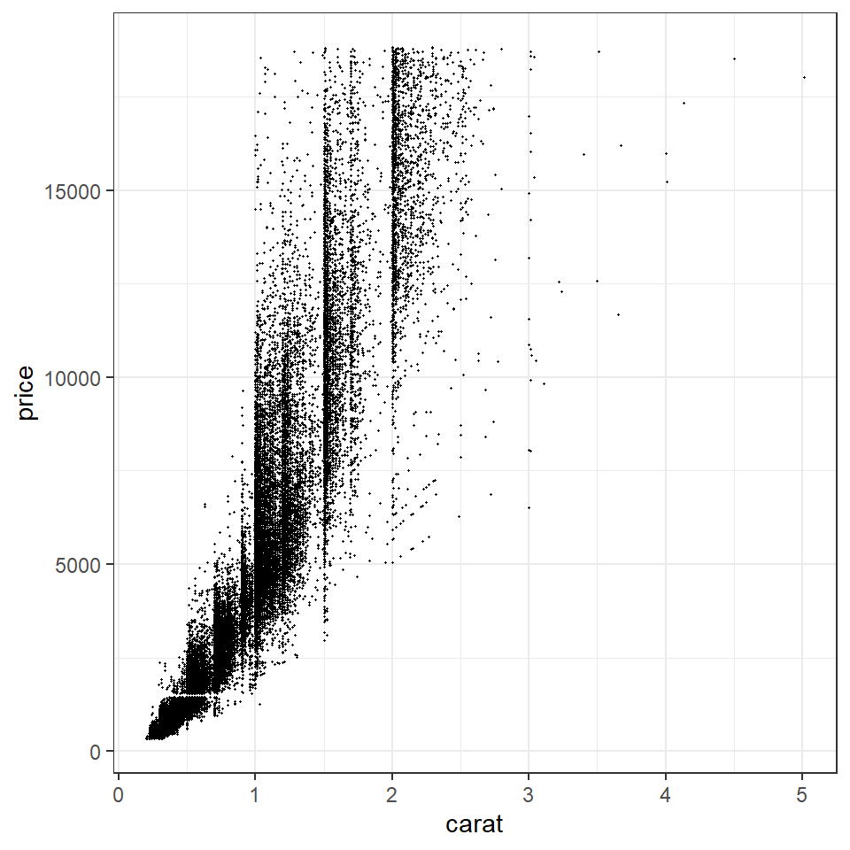

```r
ggplot(diamonds, aes(x=carat,y=price)) + geom_point(size = 0.2)
```

## A few more examples

Changing the shape and the point size

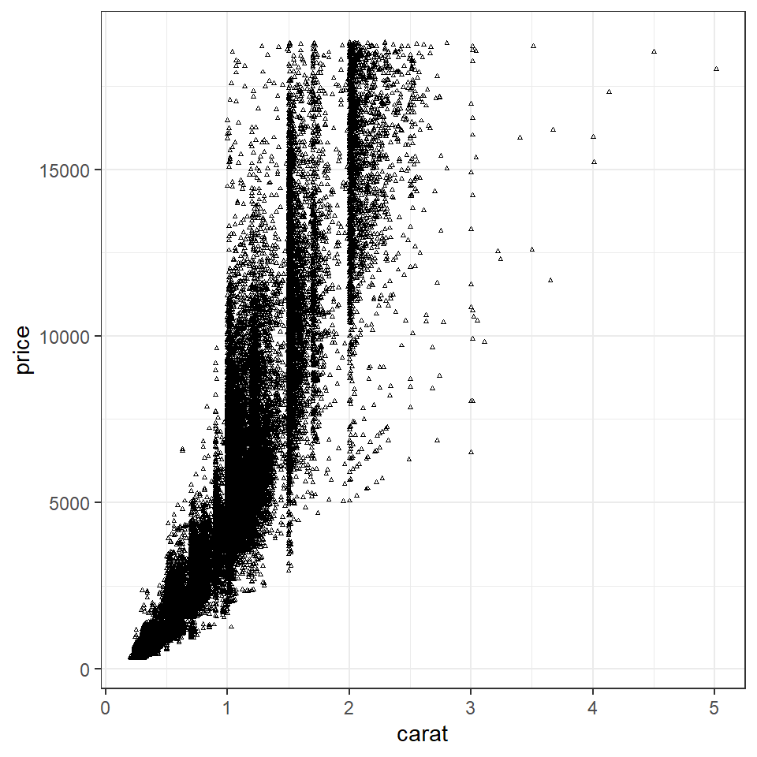

```r
ggplot(diamonds, aes(x=carat,y=price)) + geom_point(shape = 2,size=0.4)
```

## Combining layers

The real power of **ggplot** is its ability to combine layers

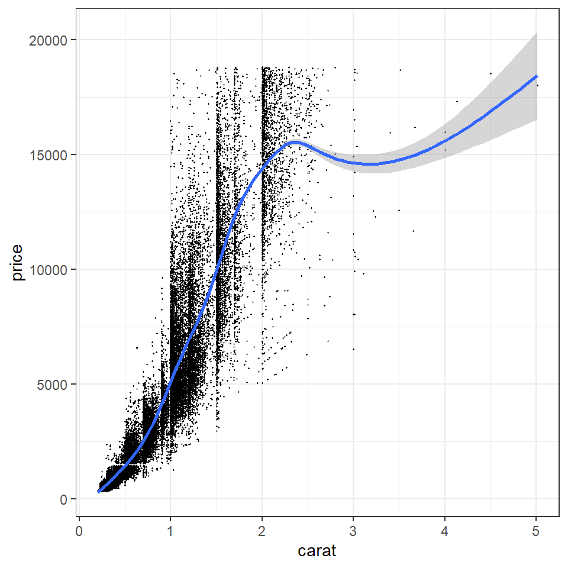

```r
ggplot(diamonds, aes(x=carat,y=price)) + geom_point(size = 0.2) +
  geom_smooth()
```

## Transformations

In this case (and many other situations) a log transformation may allow for the relationships between variables to be clearer. Can use **coord_trans()**

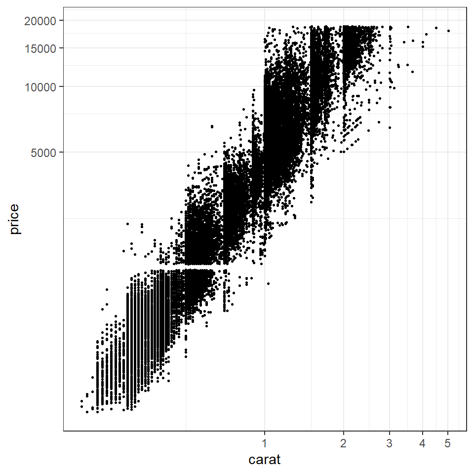

```r
ggplot(diamonds, aes(carat, price)) + geom_point(size = 0.5) +
coord_trans(x = "log10", y = "log10")
```

## Adding information for a third variable

We can color by a *factor* variable (not that it’s useful for this example!)

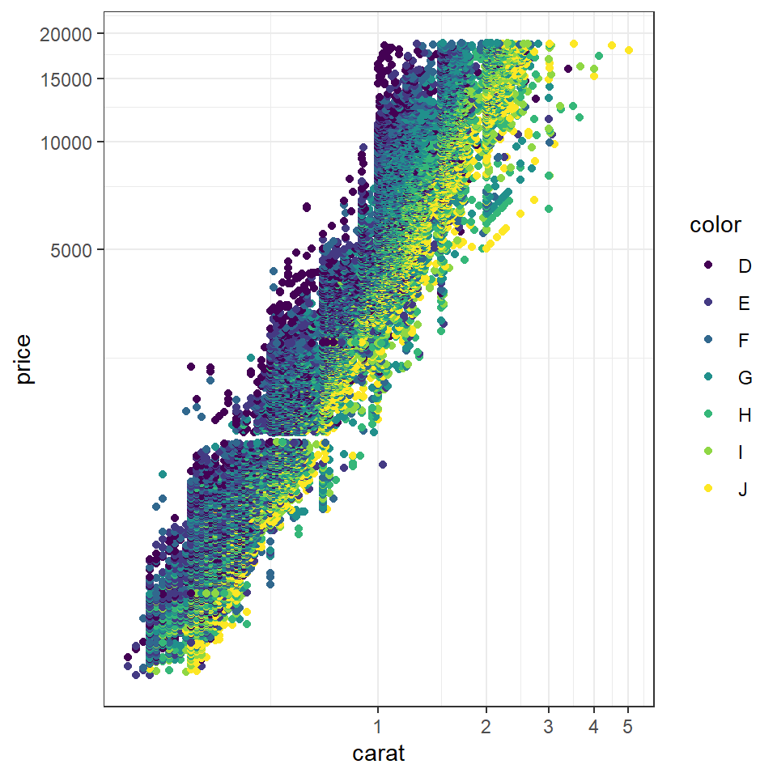

```r
ggplot(diamonds, aes(carat, price, colour=color)) + geom_point() +
    coord_trans(x = "log10", y = "log10")
```

Can also color by a *continuous* variable (not really useful for this example too, but here it is so you are familiar with the syntax:)

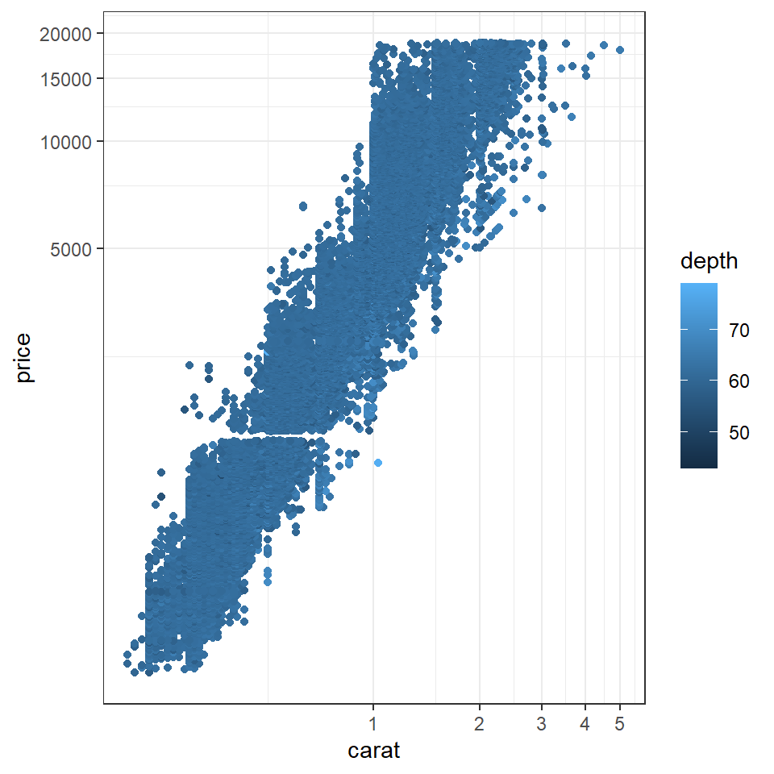

```r
ggplot(diamonds, aes(carat, price, colour=depth)) + geom_point() +
    coord_trans(x = "log10", y = "log10")
```

## Conditional plots:

In some cases, it may be more useful to get separate plots for each category of the third variable, to understand conditional relationships

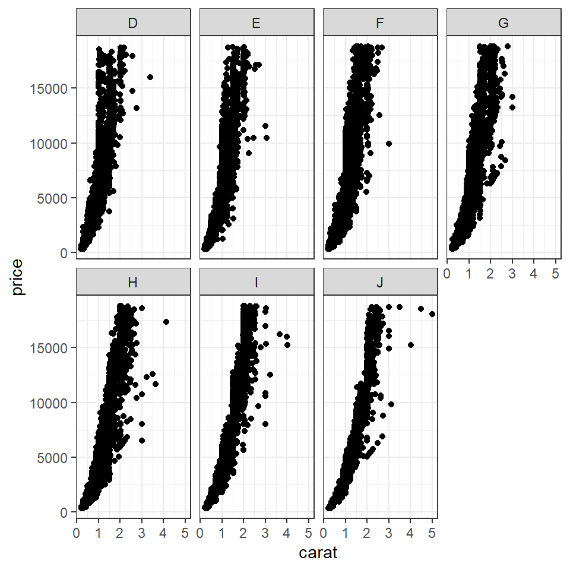

```r
ggplot(diamonds, aes(carat, price)) + geom_point() +
  facet_wrap(~color, ncol=4)
```

Alternatively, you can use **facet_grid**, which also allows more than 1 conditioning variable (tables of plots)

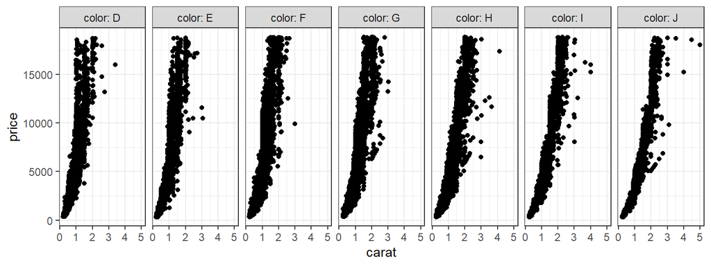

```r
ggplot(diamonds, aes(carat, price)) + geom_point() +
 facet_grid(~color, labeller=label_both)
```

## A final note about syntax

There are actually many ways to get the same plot! The following commands will produce the same plot:

- ggplot(diamonds, aes(price, carat)) + geom_point()
- ggplot() + geom_point(aes(price, carat), diamonds)
- ggplot(diamonds) + geom_point(aes(price, carat))
- ggplot(diamonds, aes(price)) + geom_point(aes(y = carat))
- ggplot(diamonds, aes(y=carat)) + geom_point(aes(x = price))

## A final summary of syntax:

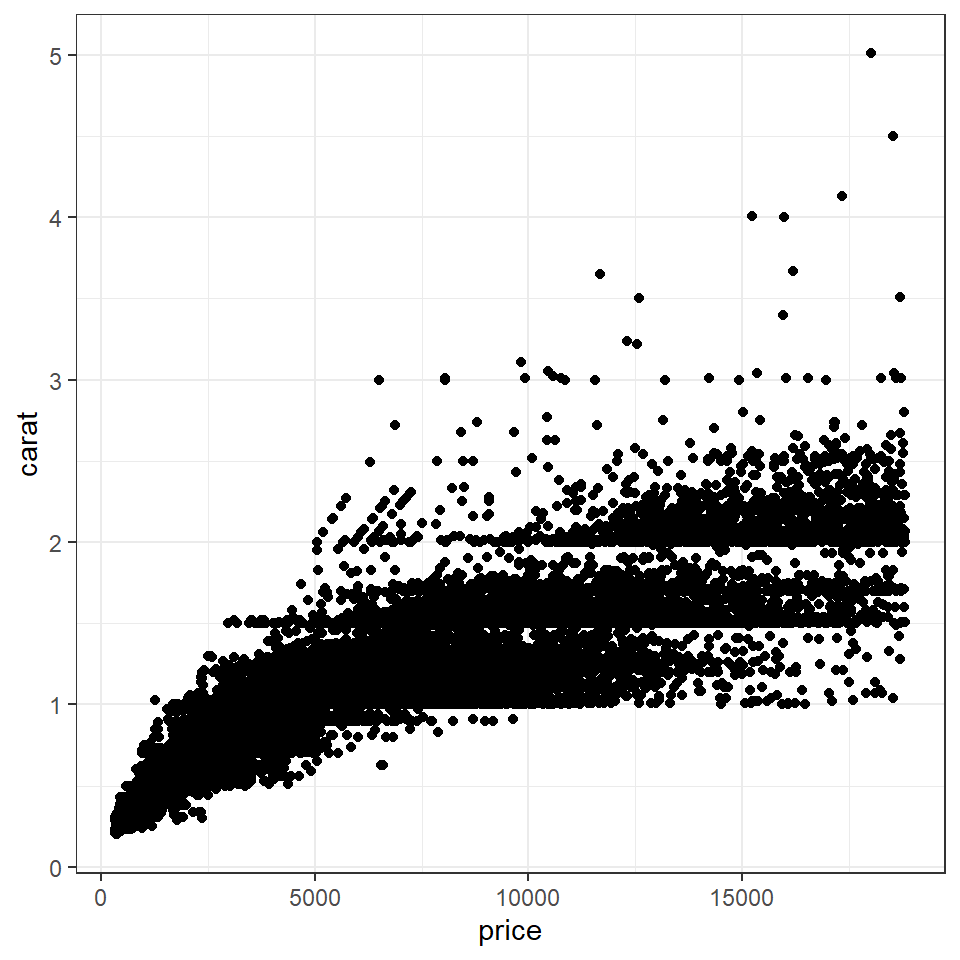

```r
ggplot(diamonds) + geom_point(aes(price, carat))
```

## Histograms

Let’s make a histogram.

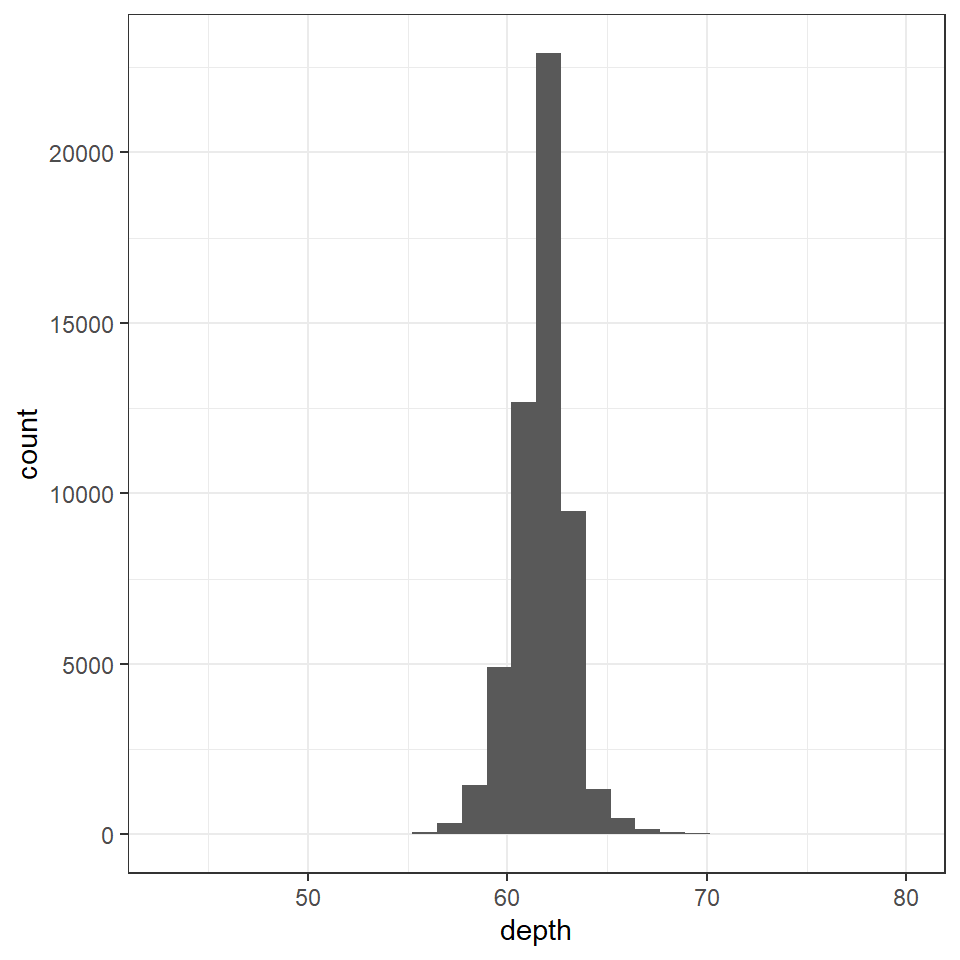

```r
ggplot(diamonds, aes(depth)) + geom_histogram()
```

## Histograms

Tthe *default options* in **histogram** may not be sensible, and you often need to adjust the **binwidth** and **xlim**

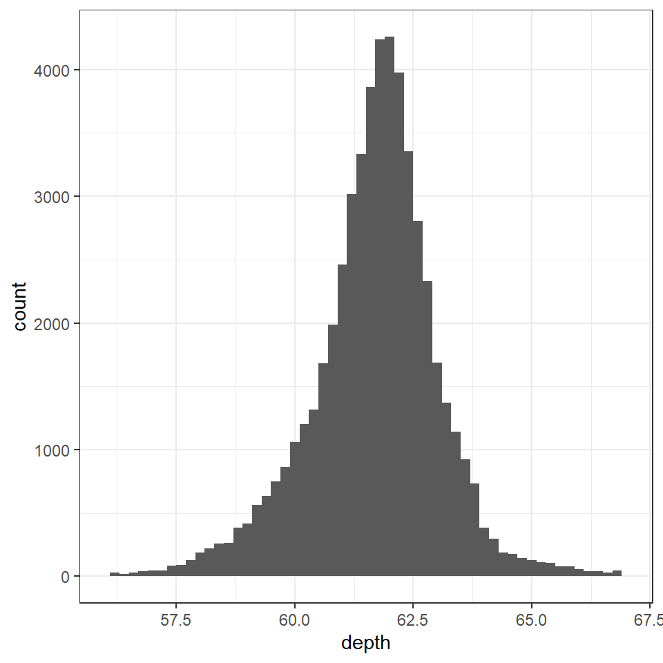

```r
ggplot(diamonds, aes(depth)) + geom_histogram(binwidth=0.2) + xlim(56,67)
```

## Boxplots with multiple categories

A better use of **boxplot** is when we want to compare distributions of a quantitative variable across categories of a factor variable, as previously discussed

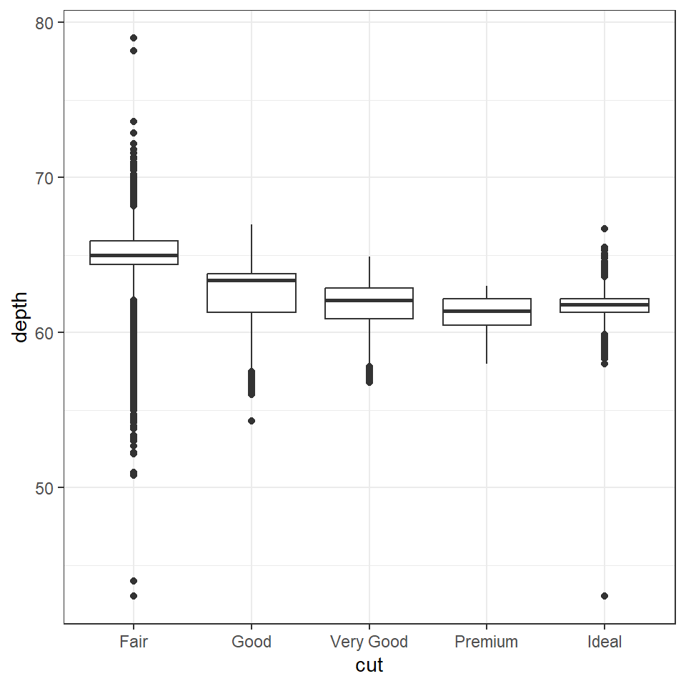

```r
ggplot(diamonds, aes(cut, depth)) + geom_boxplot()
```

## Histograms with multiple categories

We can also get multiple histograms, though we need to either display them separately (less useful when comparing)

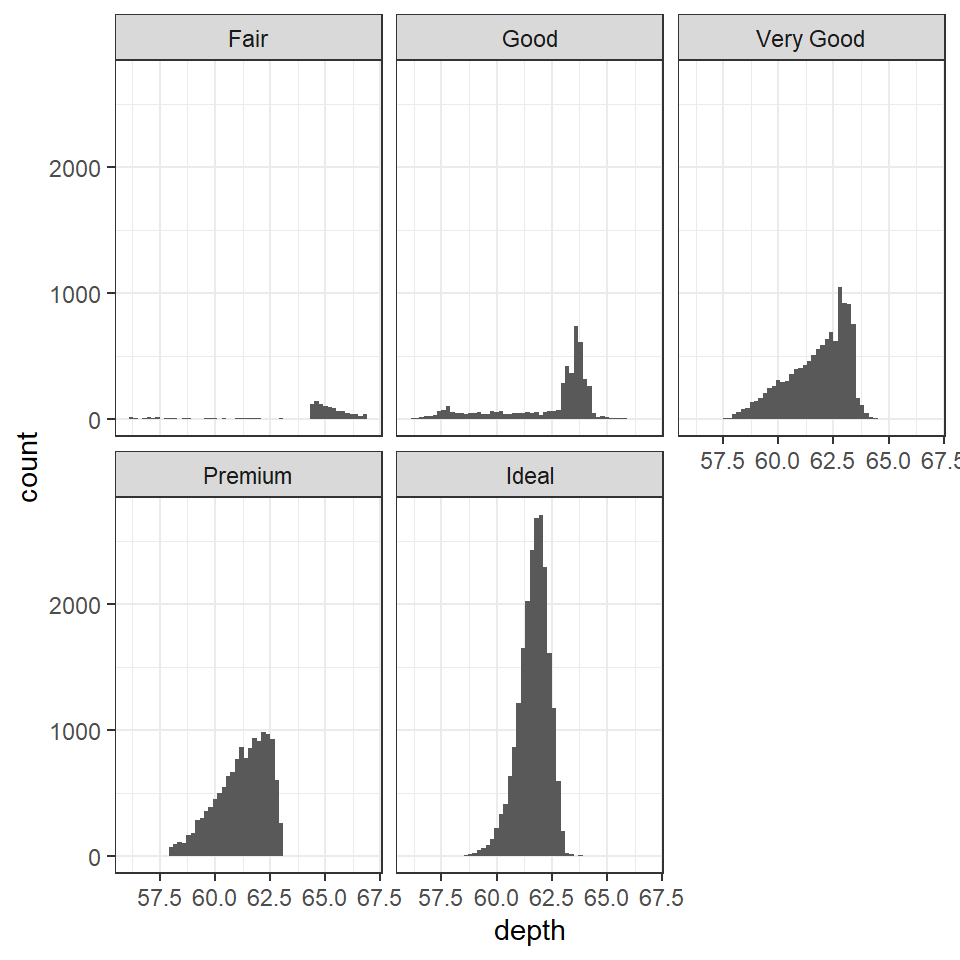

```r
ggplot(diamonds, aes(depth)) + geom_histogram(binwidth = 0.2) +
    facet_wrap(~cut) + xlim(56, 67)
```

## Overlaying Histograms

Or, you can overlay the historgrams

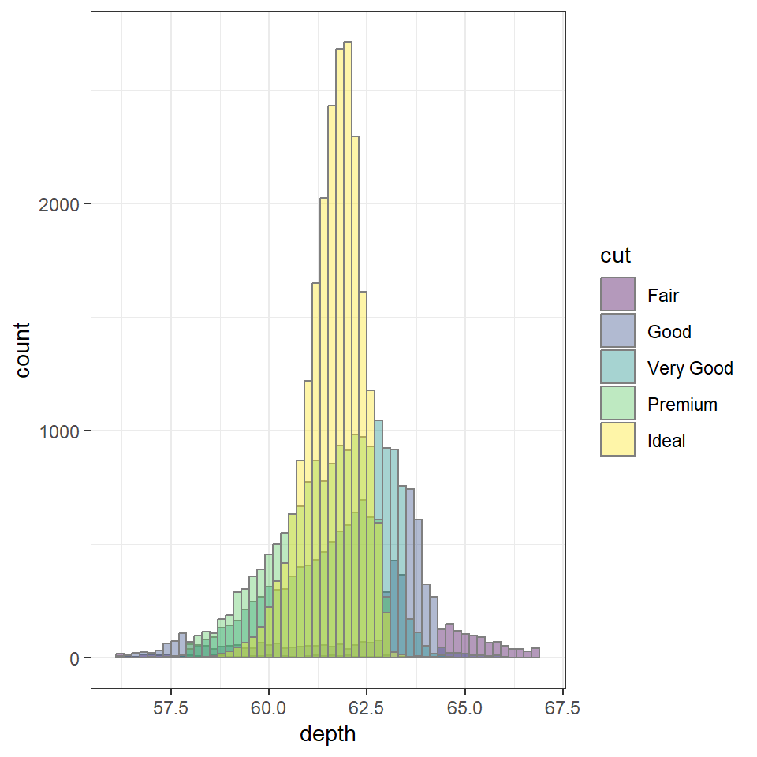

```r
ggplot(diamonds, aes(depth, fill=cut)) +
    geom_histogram(binwidth=0.2,colour="grey50",alpha=.4,position="identity") + xlim(56,67)
```

## Cheat sheet

We are covering only a few of the many plot types that can be greated with the **ggplot2** package.

For a more comprehensive view of ggplot2, take a look at the ggplot2 [Cheat sheet](https://r4ds.had.co.nz/data-visualisation.html)

## Maps

### load United States state map data

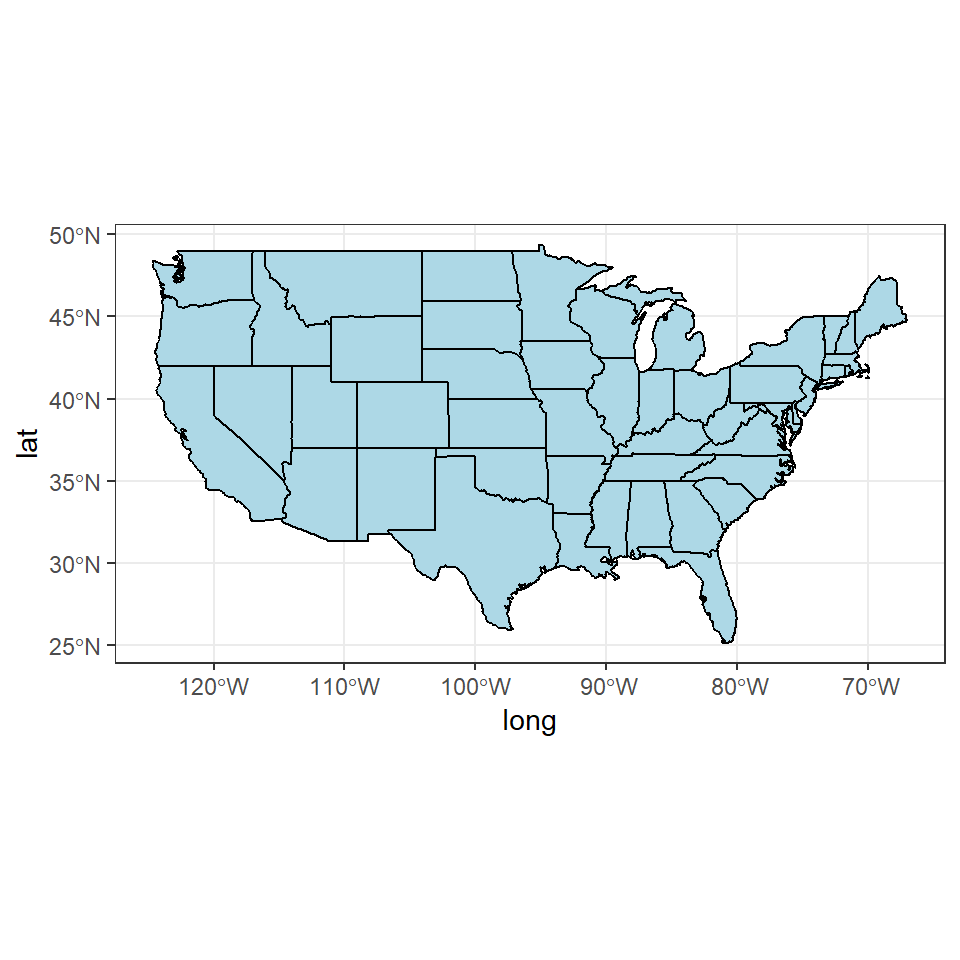

```r
#install.packages('maps') # you only need to do this once. maps package includes various maps that we can use.
#install.packages('sf') # you only need to do this once
library(maps)     # Provides latitude and longitude data for various maps
library(sf)
# read the state population data
MainStates <- map_data("state")

#plot all states with ggplot2, using black borders and light blue fill
ggplot() +
  geom_polygon( data=MainStates, aes(x=long, y=lat, group=group),
                color="black", fill="lightblue" ) +
                coord_sf(crs = st_crs(4326)) # projection
```